# Solver for problem posed on a tube

Solve a steady PDE posed on a rectangle in 2D domain.

Boundary conditions:

- $\frac{\partial}{\partial r}C(r_0,\phi)=0$, (i.e., homogeneous Neumann)
- $\frac{\partial}{\partial r}C(1,\phi)+\beta C(1,\phi)=0$, (note implemented at the moment.
- $C(r,0)=C(r,\phi)=0$ (not checked)

Solved with a standard Galerlin method.

In this example, the mesh is uniform, but we can have a Shishkin-type mesh if needed.

This code: Oct 2023, NM.

```python
import os
if "OMP_NUM_THREADS" not in os.environ:
    os.environ["OMP_NUM_THREADS"] = "1"
%matplotlib notebook
```

```python
from firedrake import *
import numpy as np

from mpl_toolkits.mplot3d import Axes3D
from matplotlib import cm
import matplotlib.pyplot as plt
from matplotlib.colors import ListedColormap
from matplotlib.tri import Triangulation

import scipy.io
from firedrake.petsc import PETSc
from datetime import datetime

from firedrake.cython import dmcommon

## Suppress TSFC quadrature warnings
#import logging
#logger = logging.getLogger("tsfc")
#logger.setLevel(ERROR)
```

```python
#comm = COMM_WORLD.Split(COMM_WORLD.rank % 2)
Solver_Params={ 'ksp_type': 'preonly', 'pc_type': 'lu',
               'pc_factor_mat_solver_type': 'mumps', 'mat_type': 'aij'}
```

## PDE data

```python
Pe = 10000
r0 = 0.01 # solve for r0<r<1
rp = 0.11 # Injection point
sigma = 0.05
G = lambda r,phi: 1/(2*np.pi*sigma**2)*exp(-( ((r-rp)/sigma)**2 + (phi/sigma)**2 ))
chi = 0.051 # stretching factor
K = 1
```

## Method data (including mesh)

Define the mesh. We'll use tensor product mesh, with $r$ and $\phi$ values stored in a numpy array. This easily adapts to a fitted mesgh.

```python
degree = 1
Nr = 512    # Number of intervals on $r$-direction
Nphi = 64  # Number of intervals on $\phi$-direction

r_mesh = np.linspace(r0,1,Nr+1)
phi_mesh = np.linspace(0,1,Nphi+1)

Mesh2D = TensorRectangleMesh(r_mesh, phi_mesh, quadrilateral=True,name="2D Smesh")

#fig1, axes1 = plt.subplots()
#triplot( Mesh2D, axes=axes1)
#axes1.axis('equal')
#fig1.tight_layout()

print(f"Solving for Nr={Nr}, Nphi={Nphi}")
```

```
Solving for Nr=512, Nphi=64
```

## 2D problem

Warnings:

1. I'm ignoring the $u(r,t)$ term;
2. I'm integrating by parts, without taking BCs into account - fix!!

```python
Ue = FiniteElement("CG", Mesh2D.ufl_cell(), degree)
V = FunctionSpace(Mesh2D, Ue)

(r,phi) = SpatialCoordinate(Mesh2D)

C = TrialFunction(V)
v = TestFunction(V)

a = inner(Pe*chi*(1-phi**2)*C.dx(1), v)*dx \
+ inner(2*(chi**2)*phi*(1-phi**2)*C.dx(1), v)*dx \
- inner(1/r*C.dx(0),v)*dx \
+ inner(C.dx(0), v.dx(0))*dx \
+ inner(chi**2*(1-phi**2)**2*C.dx(0), v.dx(0))*dx + inner(K*C,v)*dx

L = G(r,phi)*v*dx

BCs = DirichletBC(V, 0.0, [3,4]) # Dirichlet (check location???)

C_2D = Function(V)
solve(a == L, C_2D, bcs=BCs, solver_parameters=Solver_Params)
```

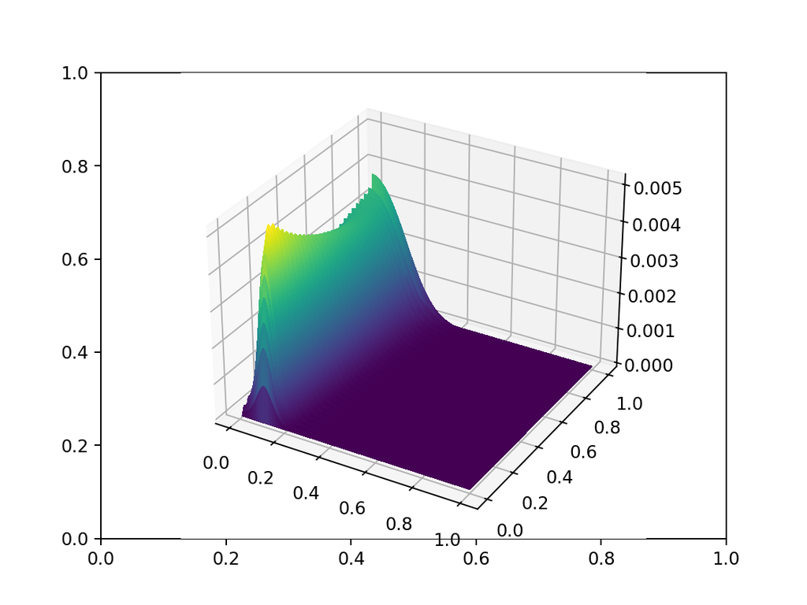

```python
fig2, axes2 = plt.subplots()
axes2 = fig2.add_subplot(111, projection='3d')
trisurf(C_2D, axes=axes2)
```

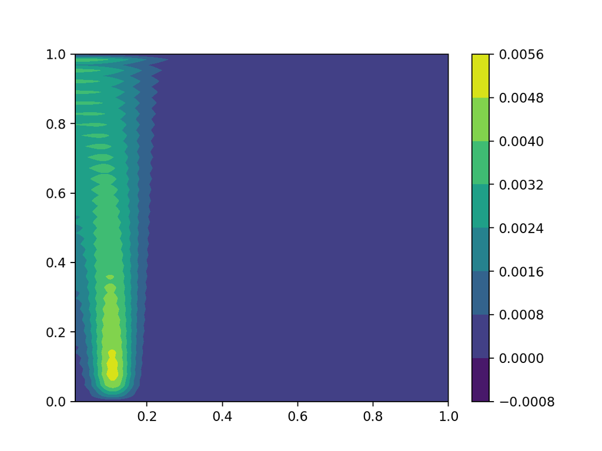

```python
fig2,axes2 = plt.subplots()
contours = tricontourf(C_2D,axes=axes2)
fig2.colorbar(contours)
```

```python
File("C_2D.pvd").write(C_2D) # view with paraview
```